# Trabalho 2

Daniel Krügel

2023-02-24

# Análise preliminar

Estarei utilizando a função de número 14, com a geração de números descrita no meu trabalho anterior.

Como neste dia em que escrevo este trabalho o trabalho 1 não foi corrigido, estarei assumindo que está coerente com o que foi ensinado em sala de aula.

Encontrei alguns problemas de inconsistência rodando a funcão `optim`, portanto irei incluir um print de quando consegui fazer ela rodar em outro computador.

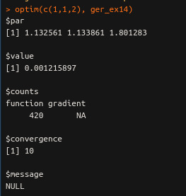

Foi utilizado os parâmetros de $\theta_1 = 1$ e $\theta_2 = 2$ para a estimação usando este optim.

Caso a resolução tenha ficado baixa, estarei encaminhando o jpeg junto ao trabalho.

Para a estimativa do erro padrão, foi utilizado o seguinte código:

```r
N <- 1000
g <- numeric(N)
for(i in 1:N){
  x <- ger_ex14(c(2,1,2))
  g[i] <- abs(x[2] - x[1])
}
mean(g)
```

```
## [1] 0.1364817
```

Foi usado como base o código disponibilizado no material complementar *http://cursos.leg.ufpr.br/ce089/09_MC_inf_estimacao.html#64_Exemplo_(erro_padr%C3%A3o)*

Em seguida foi pedido para se calcular o intervalo de confiança para a predicão do `optim()` utilizando a função `confint()`, porém ela só pode ser utilizada com modelos da classe `lm` segundo a sua documentação disponível no CRAN, portanto prossegui com a maneira analítica:

```r
# IC do meu erro padrão das estimativas com 95% de confianca:
#theta1
1.133861 + (c(-1,1)*1.96 * mean(g))
```

```
## [1] 0.8663569 1.4013651
```

```r
#Theta2
1.801283 + (c(-1,1)*1.96 * mean(g))
```

```
## [1] 1.533779 2.068787
```

Para o desvio padrão calculado apartir de jack knife foi utilizado o seguinte código:

```r
dados <- ger_ex14(c(5,1,2))
Est.test <- numeric(5)

for(i in seq(1,length(dados))){
  amostra_copy <- dados[-i]
  Est.test[i]  <- mean(amostra_copy)
}

sd(Est.test) * (length(dados)-1)/length(dados)
```

```
## [1] 0.02231634
```

Como pode,se observar, foi utilizado uma amostragem aleatória de tamanho 5.

Para os cáculos utilizando bootstrap, mantive a mesma amostra utilizada para o método de Jack knife, para se manter tudo na mesma escala:

```r
# Função para obter o estimador de interesse
estimador <- function(dados) {
  return(mean(dados))
}

# Número de reamostragens bootstrap
B <- 1000

# Bootstrap
estimativas_boot <- numeric(B)
for (i in 1:B) {
  dados_boot <- sample(dados, replace = TRUE)
  estimativas_boot[i] <- estimador(dados_boot)
}

# Estimador corrigido
estimador_corr <- mean(estimativas_boot) - (mean(estimativas_boot) - estimador(dados))

# Erro padrão
erro_padrao <- sd(estimativas_boot)

# Intervalo de confiança de 95%
quantil_inf <- quantile(estimativas_boot, 0.025)
quantil_sup <- quantile(estimativas_boot, 0.975)
intervalo_conf <- c(quantil_inf, quantil_sup)

# Resultados
cat("Estimador corrigido:", estimador_corr, "\n")
```

```
## Estimador corrigido: 0.1570109
```

```r
cat("Erro padrão:", erro_padrao, "\n")
```

```
## Erro padrão: 0.0443213
```

```r
cat("Intervalo de confiança (95%):", intervalo_conf, "\n")
```

```
## Intervalo de confiança (95%): 0.09202479 0.2565903
```

# Estudo de caso

Com toda a análise prévia, só foi necessário se criar um loop for para testar para tamanhos diferentes de amostras, como meu método de geração de números aleatórios levou em consideração apenas os parametros de $\theta_1 = 1$ e $\theta_2 = 2$ mantive eles para não precisar procurar outro ponto ótimo de M. Decidi tentar elevar a amostra em um crescimento linear enquanto o número de reamostragem bootstrap em um crescimento exponencial, porém rapidamente isso se mostrou custoso ao excesso, meu reles notebook de 12GB de memória RAM não passou do terceiro loop, portanto manterei o número de reamostras alto, porém fixo.

```r
# Para uma amostra

estimador_corr <- numeric(10)
erro_padrao <- numeric(10)
intervalo_conf <- data.frame()
tamanho_amostra_inicial <- numeric(10)

for(j in 1:10){
dados <- ger_ex14(c(j*1000,1,2))
tamanho_amostra_inicial[j] <- j*1000
# Função para obter o estimador de interesse
estimador <- function(dados) {
  return(mean(dados))
}

# Número de reamostragens bootstrap
B <- 10000

# Bootstrap
estimativas_boot <- numeric(B)
for (i in 1:B) {
  dados_boot <- sample(dados, replace = TRUE)
  estimativas_boot[i] <- estimador(dados_boot)
}

# Estimador corrigido
estimador_corr[j] <- mean(estimativas_boot) - (mean(estimativas_boot) - estimador(dados))

# Erro padrão
erro_padrao[j] <- sd(estimativas_boot)

# Intervalo de confiança de 95%
intervalo_conf[j,1] <- as.numeric(quantile(estimativas_boot, 0.025))

intervalo_conf[j,2] <- quantile(estimativas_boot, 0.975)

}
```

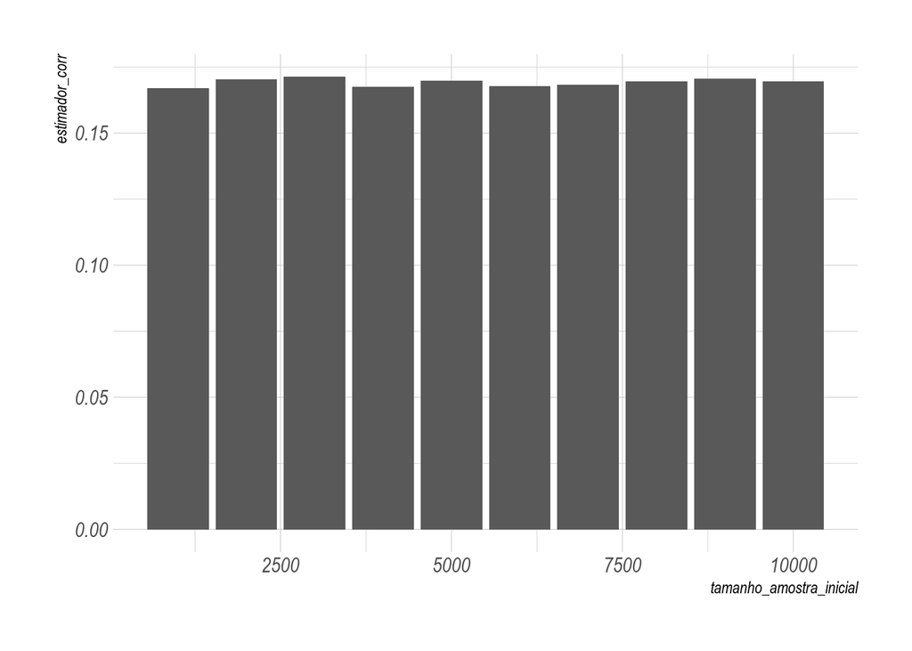

```r
par(mfrow = c(1,2))

estimador_corr.df <- data.frame(tamanho_amostra_inicial, estimador_corr)
estimador_corr.df %>%
  ggplot(aes(x = tamanho_amostra_inicial, y = estimador_corr)) +
  geom_bar(stat = "identity") +
  theme_ipsum()
```

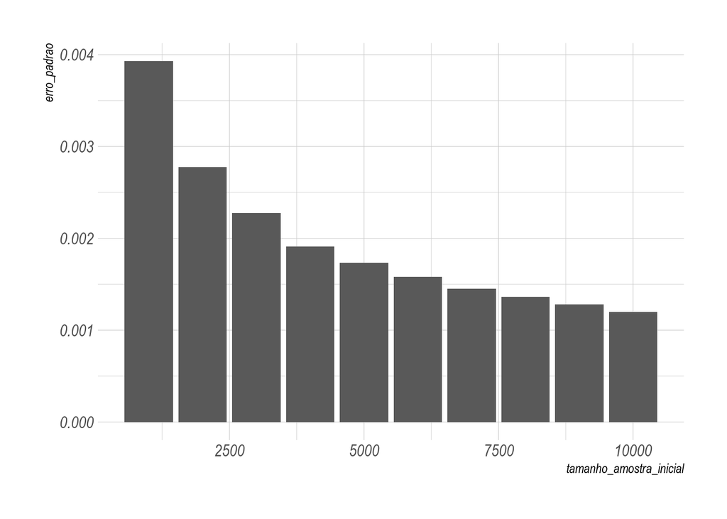

```r
erro_padrao.df <- data.frame(tamanho_amostra_inicial, erro_padrao)
erro_padrao.df %>%
  ggplot(aes(x = tamanho_amostra_inicial, y = erro_padrao)) +
  geom_bar(stat = "identity") +
  theme_ipsum()
```

Vemos que o estimador corrigido para a média se manteve constante no decorrer da quantidade de amostras iniciais, enquanto o desvio padrão caiu rapidamente, o que é coerente com a teoria de medida.

Agora olhando para o intervalo de confianca nós temos a seguinte tabela:

|  | V1 | V2 |
| --- | --- | --- |
| 1000 | 0.1595365 | 0.1750724 |
| 2000 | 0.1648758 | 0.1757034 |
| 3000 | 0.1668186 | 0.1757642 |
| 4000 | 0.1639080 | 0.1713763 |
| 5000 | 0.1666123 | 0.1733443 |
| 6000 | 0.1647797 | 0.1708930 |
| 7000 | 0.1654897 | 0.1711101 |
| 8000 | 0.1667875 | 0.1721499 |
| 9000 | 0.1681179 | 0.1731323 |
| 10000 | 0.1673157 | 0.1720690 |

# Para várias amostras

Reaplicando a mesma teoria anterior, mantendo 4 tamanhos de amostras mas gerando 500 de cada

```r
estimador_corr1000 <- numeric(500)
estimador_corr5 <- numeric(500)
estimador_corr10 <- numeric(500)
estimador_corr100 <- numeric(500)

erro_padrao1000 <- numeric(500)
erro_padrao5 <- numeric(500)
erro_padrao10 <- numeric(500)
erro_padrao100 <- numeric(500)

intervalo_conf5 <- data.frame()
intervalo_conf10 <- data.frame()
intervalo_conf100 <- data.frame()
intervalo_conf1000 <- data.frame()


estimativas_boot5 <- numeric(B)
estimativas_boot10 <- numeric(B)
estimativas_boot100 <- numeric(B)
estimativas_boot1000 <- numeric(B)
B <- 1000



for(j in 1:500){
dados1000 <- ger_ex14(c(1000,1,2))
dados5 <- ger_ex14(c(5,1,2))
dados10 <- ger_ex14(c(10,1,2))
dados100 <- ger_ex14(c(100,1,2))

# Função para obter o estimador de interesse
estimador <- function(dados1000) {
  return(mean(dados1000))
}

# Número de reamostragens bootstrap
#B <- 10000

# Bootstrap

for (i in 1:B) {
  dados1000_boot <- sample(dados1000, replace = TRUE)
  estimativas_boot1000[i] <- estimador(dados1000_boot)
  dados5_boot <- sample(dados5, replace = TRUE)
  estimativas_boot5[i] <- estimador(dados5_boot)
  dados10_boot <- sample(dados10, replace = TRUE)
  estimativas_boot10[i] <- estimador(dados10_boot)
  dados100_boot <- sample(dados100, replace = TRUE)
  estimativas_boot100[i] <- estimador(dados100_boot)
  }

# Estimador corrigido
estimador_corr5[j] <- mean(estimativas_boot5) - (mean(estimativas_boot5) - estimador(dados5))
estimador_corr10[j] <- mean(estimativas_boot10) - (mean(estimativas_boot10) - estimador(dados10))
estimador_corr100[j] <- mean(estimativas_boot100) - (mean(estimativas_boot100) - estimador(dados100))
estimador_corr1000[j] <- mean(estimativas_boot1000) - (mean(estimativas_boot1000) - estimador(dados1000))

# Erro padrão
erro_padrao1000[j] <- sd(estimativas_boot1000)
erro_padrao5[j] <- sd(estimativas_boot5)
erro_padrao10[j] <- sd(estimativas_boot10)
erro_padrao100[j] <- sd(estimativas_boot100)




# Intervalo de confiança de 95%
intervalo_conf1000[j,1] <- as.numeric(quantile(estimativas_boot, 0.025))
intervalo_conf1000[j,2] <- quantile(estimativas_boot, 0.975)

intervalo_conf5[j,1] <- as.numeric(quantile(estimativas_boot5, 0.025))
intervalo_conf5[j,2] <- quantile(estimativas_boot5, 0.975)

intervalo_conf10[j,1] <- as.numeric(quantile(estimativas_boot10, 0.025))
intervalo_conf10[j,2] <- quantile(estimativas_boot10, 0.975)

intervalo_conf100[j,1] <- as.numeric(quantile(estimativas_boot100, 0.025))
intervalo_conf100[j,2] <- quantile(estimativas_boot100, 0.975)

}
```

Um gráfico comparando a média dos estimadores bootstrap para cada um do tamanho das amostras:

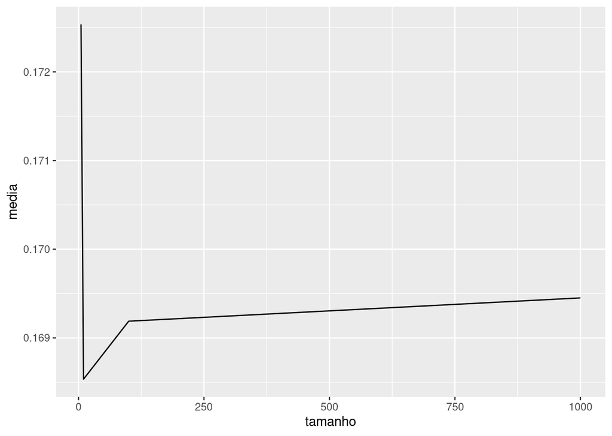

```r
comp.estimador <- t(data.frame("5" = mean(estimador_corr5), "10" = mean(estimador_corr10), "100" = mean(estimador_corr100), "1000" = mean(estimador_corr1000)))
colnames(comp.estimador) <- c("media")
comp.estimador <- as.data.frame(comp.estimador)
comp.estimador$tamanho <- c(5,10,100,1000)

ggplot(comp.estimador, aes(x = tamanho ,y = media)) +
  geom_line()
```

# Jack knife

```r
erro_padrao_jk <- numeric(4)
tam_amostra <- numeric(4)


for(k in 1:4){
  Amostra <- ger_ex14(c(k*1000, 1, 2))
  tam_amostra[k] <- k*1000
  Est.test <- numeric(k*1000)
for(i in seq(1,length(Amostra))){
  amostra_copy <- Amostra[-i]
  Est.test[i]  <- mean(amostra_copy)
}

erro_padrao_jk[k]<- sd(Est.test) * (length(Amostra)-1)/length(Amostra)
}

erro_padrao_jk.df <- data.frame(tam_amostra, erro_padrao_jk)
erro_padrao_jk.df
```

| tam_amostra | erro_padrao_jk |
| --- | --- |
| 1000 | 1.230650e-04 |
| 2000 | 6.256457e-05 |
| 3000 | 4.158675e-05 |
| 4000 | 3.024783e-05 |

Este arquivo .pdf e .Rmd, assim como o enunciado deste trabalho ficaram disponíveis no meu repositório público para uso pessoal, didático e avaliativo. Os arquivos podem ser encontrados em DKrugel/Faculdade